# Unsupervised Learning: Trade&Ahead

**Marks: 60**

### Context

The stock market has consistently proven to be a good place to invest in and save for the future. There are a lot of compelling reasons to invest in stocks. It can help in fighting inflation, create wealth, and also provides some tax benefits. Good steady returns on investments over a long period of time can also grow a lot more than seems possible. Also, thanks to the power of compound interest, the earlier one starts investing, the larger the corpus one can have for retirement. Overall, investing in stocks can help meet life's financial aspirations.

It is important to maintain a diversified portfolio when investing in stocks in order to maximise earnings under any market condition. Having a diversified portfolio tends to yield higher returns and face lower risk by tempering potential losses when the market is down. It is often easy to get lost in a sea of financial metrics to analyze while determining the worth of a stock, and doing the same for a multitude of stocks to identify the right picks for an individual can be a tedious task. By doing a cluster analysis, one can identify stocks that exhibit similar characteristics and ones which exhibit minimum correlation. This will help investors better analyze stocks across different market segments and help protect against risks that could make the portfolio vulnerable to losses.

### Objective

Trade&Ahead is a financial consultancy firm who provide their customers with personalized investment strategies. They have hired you as a Data Scientist and provided you with data comprising stock price and some financial indicators for a few companies listed under the New York Stock Exchange. They have assigned you the tasks of analyzing the data, grouping the stocks based on the attributes provided, and sharing insights about the characteristics of each group.

### Data Dictionary

- Ticker Symbol: An abbreviation used to uniquely identify publicly traded shares of a particular stock on a particular stock market
- Company: Name of the company
- GICS Sector: The specific economic sector assigned to a company by the Global Industry Classification Standard (GICS) that best defines its business operations
- GICS Sub Industry: The specific sub-industry group assigned to a company by the Global Industry Classification Standard (GICS) that best defines its business operations
- Current Price: Current stock price in dollars
- Price Change: Percentage change in the stock price in 13 weeks
- Volatility: Standard deviation of the stock price over the past 13 weeks
- ROE: A measure of financial performance calculated by dividing net income by shareholders' equity (shareholders' equity is equal to a company's assets minus its debt)
- Cash Ratio: The ratio of a company's total reserves of cash and cash equivalents to its total current liabilities
- Net Cash Flow: The difference between a company's cash inflows and outflows (in dollars)
- Net Income: Revenues minus expenses, interest, and taxes (in dollars)
- Earnings Per Share: Company's net profit divided by the number of common shares it has outstanding (in dollars)
- Estimated Shares Outstanding: Company's stock currently held by all its shareholders
- P/E Ratio: Ratio of the company's current stock price to the earnings per share
- P/B Ratio: Ratio of the company's stock price per share by its book value per share (book value of a company is the net difference between that company's total assets and total liabilities)

## Importing necessary libraries and data

```python
# To filter the warnings
import warnings
warnings.filterwarnings("ignore")

# Libraries to help with reading and manipulating data
import pandas as pd
import numpy as np

# libaries to help with data visualization
import matplotlib.pyplot as plt
%matplotlib inline
import seaborn as sns

# Library to split data
from sklearn.model_selection import train_test_split

# to scale the data using z-score
from sklearn.preprocessing import StandardScaler

# to compute distances
from scipy.spatial.distance import cdist

# to perform k-means clustering and compute silhouette scores
from sklearn.cluster import KMeans
from sklearn.metrics import silhouette_score

# to visualize the elbow curve and silhouette scores
from yellowbrick.cluster import KElbowVisualizer, SilhouetteVisualizer

# Removes the limit for the number of displayed columns
pd.set_option("display.max_columns", None)
# Sets the limit for the number of displayed rows
pd.set_option("display.max_rows", 200)

# to compute distances
from scipy.spatial.distance import pdist

# to perform hierarchical clustering, compute cophenetic correlation, and create dendrograms
from sklearn.cluster import AgglomerativeClustering
from scipy.cluster.hierarchy import dendrogram, linkage, cophenet
```

## Data Overview

- Observations
- Sanity checks

```python
# Loading the dataset
from google.colab import drive
drive.mount('/content/drive')

# read the data
path="/content/drive/MyDrive/Colab Notebooks/Great Learning 7/stock_data.csv"
stock_df = pd.read_csv(path)
stock_df.dtypes
```

```
Ticker Symbol                    object
Security                         object
GICS Sector                      object
GICS Sub Industry                object
Current Price                   float64
Price Change                    float64
Volatility                      float64
ROE                               int64
Cash Ratio                        int64
Net Cash Flow                     int64
Net Income                        int64
Earnings Per Share              float64
Estimated Shares Outstanding    float64
P/E Ratio                       float64
P/B Ratio                       float64
dtype: object
```

```python
# returns the first 5 rows
stock_df.head()
```

|  | Ticker Symbol | Security | GICS Sector | GICS Sub Industry | Current Price | Price Change | Volatility | ROE | Cash Ratio | Net Cash Flow | Net Income | Earnings Per Share | Estimated Shares Outstanding | P/E Ratio | P/B Ratio |
| --- | --- | --- | --- | --- | --- | --- | --- | --- | --- | --- | --- | --- | --- | --- | --- |
| 0 | AAL | American Airlines Group | Industrials | Airlines | 42.349998 | 9.999995 | 1.687151 | 135 | 51 | -604000000 | 7610000000 | 11.39 | 6.681299e+08 | 3.718174 | -8.784219 |
| 1 | ABBV | AbbVie | Health Care | Pharmaceuticals | 59.240002 | 8.339433 | 2.197887 | 130 | 77 | 51000000 | 5144000000 | 3.15 | 1.633016e+09 | 18.806350 | -8.750068 |
| 2 | ABT | Abbott Laboratories | Health Care | Health Care Equipment | 44.910000 | 11.301121 | 1.273646 | 21 | 67 | 938000000 | 4423000000 | 2.94 | 1.504422e+09 | 15.275510 | -0.394171 |
| 3 | ADBE | Adobe Systems Inc | Information Technology | Application Software | 93.940002 | 13.977195 | 1.357679 | 9 | 180 | -240840000 | 629551000 | 1.26 | 4.996437e+08 | 74.555557 | 4.199651 |
| 4 | ADI | Analog Devices, Inc. | Information Technology | Semiconductors | 55.320000 | -1.827858 | 1.701169 | 14 | 272 | 315120000 | 696878000 | 0.31 | 2.247994e+09 | 178.451613 | 1.059810 |

```python
# Shape of the data set
stock_df.shape
```

```
(340, 15)
```

**There are 340 rows and 15 columns in the stock dataset**

```python
# Data type and null count of the dataset
stock_df.info()
```

```
<class 'pandas.core.frame.DataFrame'>
RangeIndex: 340 entries, 0 to 339
Data columns (total 15 columns):
 #   Column                        Non-Null Count  Dtype
---  ------                        --------------  -----
 0   Ticker Symbol                 340 non-null    object
 1   Security                      340 non-null    object
 2   GICS Sector                   340 non-null    object
 3   GICS Sub Industry             340 non-null    object
 4   Current Price                 340 non-null    float64
 5   Price Change                  340 non-null    float64
 6   Volatility                    340 non-null    float64
 7   ROE                           340 non-null    int64
 8   Cash Ratio                    340 non-null    int64
 9   Net Cash Flow                 340 non-null    int64
 10  Net Income                    340 non-null    int64
 11  Earnings Per Share            340 non-null    float64
 12  Estimated Shares Outstanding  340 non-null    float64
 13  P/E Ratio                     340 non-null    float64
 14  P/B Ratio                     340 non-null    float64
dtypes: float64(7), int64(4), object(4)
memory usage: 40.0+ KB
```

**There are no missing values in the dataset**

```python
stock_df.isna().sum()
```

```
Ticker Symbol                   0
Security                        0
GICS Sector                     0
GICS Sub Industry               0
Current Price                   0
Price Change                    0
Volatility                      0
ROE                             0
Cash Ratio                      0
Net Cash Flow                   0
Net Income                      0
Earnings Per Share              0
Estimated Shares Outstanding    0
P/E Ratio                       0
P/B Ratio                       0
dtype: int64
```

```python
# Checking duplicates
stock_df.duplicated().sum()
```

```
0
```

**There are no duplicate in the dataset**

```python
# Creating copy of the dataset
stock_df2 = stock_df.copy()
```

```python
# Summary of the dataset
stock_df2.describe(include='all').T
```

|  | count | unique | top | freq | mean | std | min | 25% | 50% | 75% | max |
| --- | --- | --- | --- | --- | --- | --- | --- | --- | --- | --- | --- |
| Ticker Symbol | 340 | 340 | AAL | 1 | NaN | NaN | NaN | NaN | NaN | NaN | NaN |
| Security | 340 | 340 | American Airlines Group | 1 | NaN | NaN | NaN | NaN | NaN | NaN | NaN |
| GICS Sector | 340 | 11 | Industrials | 53 | NaN | NaN | NaN | NaN | NaN | NaN | NaN |
| GICS Sub Industry | 340 | 104 | Oil & Gas Exploration & Production | 16 | NaN | NaN | NaN | NaN | NaN | NaN | NaN |
| Current Price | 340.0 | NaN | NaN | NaN | 80.862345 | 98.055086 | 4.5 | 38.555 | 59.705 | 92.880001 | 1274.949951 |
| Price Change | 340.0 | NaN | NaN | NaN | 4.078194 | 12.006338 | -47.129693 | -0.939484 | 4.819505 | 10.695493 | 55.051683 |
| Volatility | 340.0 | NaN | NaN | NaN | 1.525976 | 0.591798 | 0.733163 | 1.134878 | 1.385593 | 1.695549 | 4.580042 |
| ROE | 340.0 | NaN | NaN | NaN | 39.597059 | 96.547538 | 1.0 | 9.75 | 15.0 | 27.0 | 917.0 |
| Cash Ratio | 340.0 | NaN | NaN | NaN | 70.023529 | 90.421331 | 0.0 | 18.0 | 47.0 | 99.0 | 958.0 |
| Net Cash Flow | 340.0 | NaN | NaN | NaN | 55537620.588235 | 1946365312.175789 | -11208000000.0 | -193906500.0 | 2098000.0 | 169810750.0 | 20764000000.0 |
| Net Income | 340.0 | NaN | NaN | NaN | 1494384602.941176 | 3940150279.327936 | -23528000000.0 | 352301250.0 | 707336000.0 | 1899000000.0 | 24442000000.0 |
| Earnings Per Share | 340.0 | NaN | NaN | NaN | 2.776662 | 6.587779 | -61.2 | 1.5575 | 2.895 | 4.62 | 50.09 |
| Estimated Shares Outstanding | 340.0 | NaN | NaN | NaN | 577028337.75403 | 845849595.417695 | 27672156.86 | 158848216.1 | 309675137.8 | 573117457.325 | 6159292035.0 |
| P/E Ratio | 340.0 | NaN | NaN | NaN | 32.612563 | 44.348731 | 2.935451 | 15.044653 | 20.819876 | 31.764755 | 528.039074 |
| P/B Ratio | 340.0 | NaN | NaN | NaN | -1.718249 | 13.966912 | -76.119077 | -4.352056 | -1.06717 | 3.917066 | 129.064585 |

### **Observation from data**

Stock dataset has 340 rows and 15 columns. It does not have any missing values.

```python
# Checking different counts of categorical variables in dataset
for i in stock_df2.columns:
    if stock_df2[i].dtypes == object:
        print('There are',stock_df2[i].nunique(),'Different type of', i ,'for the easy visa dataset and its counts in dataset as below')
        display()
        display(stock_df2[i].value_counts(normalize=True))
        display(stock_df2[i].value_counts())
        print('----------------------------------------------------------------------------')
```

```
There are 340 Different type of Ticker Symbol for the easy visa dataset and its counts in dataset as below
```

```
AAL     0.002941
NEE     0.002941
NUE     0.002941
NTRS    0.002941
NSC     0.002941
          ...
EQR     0.002941
EQIX    0.002941
EOG     0.002941
EMN     0.002941
ZTS     0.002941
Name: Ticker Symbol, Length: 340, dtype: float64
```

```
AAL     1
NEE     1
NUE     1
NTRS    1
NSC     1
       ..
EQR     1
EQIX    1
EOG     1
EMN     1
ZTS     1
Name: Ticker Symbol, Length: 340, dtype: int64
```

```
----------------------------------------------------------------------------
There are 340 Different type of Security for the easy visa dataset and its counts in dataset as below
```

```
American Airlines Group    0.002941
NextEra Energy             0.002941
Nucor Corp.                0.002941
Northern Trust Corp.       0.002941
Norfolk Southern Corp.     0.002941
                             ...
Equity Residential         0.002941
Equinix                    0.002941
EOG Resources              0.002941
Eastman Chemical           0.002941
Zoetis                     0.002941
Name: Security, Length: 340, dtype: float64
```

```
American Airlines Group    1
NextEra Energy             1
Nucor Corp.                1
Northern Trust Corp.       1
Norfolk Southern Corp.     1
                          ..
Equity Residential         1
Equinix                    1
EOG Resources              1
Eastman Chemical           1
Zoetis                     1
Name: Security, Length: 340, dtype: int64
```

```
----------------------------------------------------------------------------
There are 11 Different type of GICS Sector for the easy visa dataset and its counts in dataset as below
```

```
Industrials                    0.155882
Financials                     0.144118
Health Care                    0.117647
Consumer Discretionary         0.117647
Information Technology         0.097059
Energy                         0.088235
Real Estate                    0.079412
Utilities                      0.070588
Materials                      0.058824
Consumer Staples               0.055882
Telecommunications Services    0.014706
Name: GICS Sector, dtype: float64
```

```
Industrials                    53
Financials                     49
Health Care                    40
Consumer Discretionary         40
Information Technology         33
Energy                         30
Real Estate                    27
Utilities                      24
Materials                      20
Consumer Staples               19
Telecommunications Services     5
Name: GICS Sector, dtype: int64
```

```
----------------------------------------------------------------------------
There are 104 Different type of GICS Sub Industry for the easy visa dataset and its counts in dataset as below
```

```
Oil & Gas Exploration & Production                 0.047059
REITs                                              0.041176
Industrial Conglomerates                           0.041176
Electric Utilities                                 0.035294
Internet Software & Services                       0.035294
Health Care Equipment                              0.032353
MultiUtilities                                     0.032353
Banks                                              0.029412
Property & Casualty Insurance                      0.023529
Diversified Financial Services                     0.020588
Biotechnology                                      0.020588
Pharmaceuticals                                    0.017647
Packaged Foods & Meats                             0.017647
Oil & Gas Refining & Marketing & Transportation    0.017647
Semiconductors                                     0.017647
Diversified Chemicals                              0.014706
Consumer Finance                                   0.014706
Integrated Oil & Gas                               0.014706
Industrial Machinery                               0.014706
Managed Health Care                                0.014706
Airlines                                           0.014706
Health Care Facilities                             0.014706
Internet & Direct Marketing Retail                 0.011765
Residential REITs                                  0.011765
Retail REITs                                       0.011765
Soft Drinks                                        0.011765
Research & Consulting Services                     0.011765
Asset Management & Custody Banks                   0.011765
Specialty Chemicals                                0.011765
Railroads                                          0.011765
Aerospace & Defense                                0.011765
Integrated Telecommunications Services             0.011765
Building Products                                  0.011765
Hotels, Resorts & Cruise Lines                     0.011765
Restaurants                                        0.008824
Cable & Satellite                                  0.008824
Air Freight & Logistics                            0.008824
Household Products                                 0.008824
Regional Banks                                     0.008824
IT Consulting & Other Services                     0.008824
```

[output cut: 50 more lines]

```
Semiconductor Equipment                            0.002941
Multi-line Insurance                               0.002941
Copper                                             0.002941
Electronic Equipment & Instruments                 0.002941
Diversified Commercial Services                    0.002941
Consumer Electronics                               0.002941
Tires & Rubber                                     0.002941
Industrial Materials                               0.002941
Motorcycle Manufacturers                           0.002941
Technology Hardware, Storage & Peripherals         0.002941
Real Estate Services                               0.002941
Trucking                                           0.002941
Networking Equipment                               0.002941
Casinos & Gaming                                   0.002941
Name: GICS Sub Industry, dtype: float64
```

```
Oil & Gas Exploration & Production                 16
REITs                                              14
Industrial Conglomerates                           14
Electric Utilities                                 12
Internet Software & Services                       12
Health Care Equipment                              11
MultiUtilities                                     11
Banks                                              10
Property & Casualty Insurance                       8
Diversified Financial Services                      7
Biotechnology                                       7
Pharmaceuticals                                     6
Packaged Foods & Meats                              6
Oil & Gas Refining & Marketing & Transportation     6
Semiconductors                                      6
Diversified Chemicals                               5
Consumer Finance                                    5
Integrated Oil & Gas                                5
Industrial Machinery                                5
Managed Health Care                                 5
Airlines                                            5
Health Care Facilities                              5
Internet & Direct Marketing Retail                  4
Residential REITs                                   4
Retail REITs                                        4
Soft Drinks                                         4
Research & Consulting Services                      4
Asset Management & Custody Banks                    4
Specialty Chemicals                                 4
Railroads                                           4
Aerospace & Defense                                 4
Integrated Telecommunications Services              4
Building Products                                   4
Hotels, Resorts & Cruise Lines                      4
Restaurants                                         3
Cable & Satellite                                   3
Air Freight & Logistics                             3
Household Products                                  3
Regional Banks                                      3
IT Consulting & Other Services                      3
```

[output cut: 50 more lines]

```
Semiconductor Equipment                             1
Multi-line Insurance                                1
Copper                                              1
Electronic Equipment & Instruments                  1
Diversified Commercial Services                     1
Consumer Electronics                                1
Tires & Rubber                                      1
Industrial Materials                                1
Motorcycle Manufacturers                            1
Technology Hardware, Storage & Peripherals          1
Real Estate Services                                1
Trucking                                            1
Networking Equipment                                1
Casinos & Gaming                                    1
Name: GICS Sub Industry, dtype: int64
```

## Exploratory Data Analysis (EDA)

### **Univariate Analysis**

```python
# Getting percent on bar plot
def barplot_values_percent(ax):
    heightlst = []
    for i in ax.patches:
        heightlst.append(i.get_height())
    total = sum(heightlst)

    for i in ax.patches:
        x = i.get_x()+0.05 #adjust the numbers (higher numbers = to the right, lower = to the left)
        height = i.get_height()+0.1 #adjust the numbers (higher numbers = up, lower = down)
        value = ("{0:.2f}".format((i.get_height()/total)*100)+'%')

        ax.text(x, height, value, fontsize=10,color='red')
```

```python
# Getting median on box plot
import matplotlib.patheffects as path_effects

def add_median_labels(ax, fmt='.1f'):
    lines = ax.get_lines()
    boxes = [c for c in ax.get_children() if type(c).__name__ == 'PathPatch']
    lines_per_box = int(len(lines) / len(boxes))
    for median in lines[4:len(lines):lines_per_box]:
        x, y = (data.mean() for data in median.get_data())
        # choose value depending on horizontal or vertical plot orientation
        value = x if (median.get_xdata()[1] - median.get_xdata()[0]) == 0 else y
        text = ax.text(x, y, f'{value:{fmt}}', ha='center', va='center',
                       fontweight='bold', color='white')
        # create median-colored border around white text for contrast
        text.set_path_effects([
            path_effects.Stroke(linewidth=3, foreground=median.get_color()),
            path_effects.Normal(),
        ])
```

```python
# Histplot,boxplot and count plot function
def hist(fea,df,kde):
    sns.histplot(x=fea,data=df,kde=kde)
    plt.show()
def box(fea,df):
    ax = sns.boxplot(x=fea,data=df)
    add_median_labels(ax)
    plt.show()
def count(fea,df):

     ax = sns.countplot(x=fea,data=df)
     barplot_values_percent(ax)
     plt.show()
```

**What does the distribution of stock prices look like?**

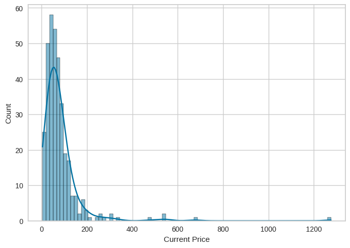

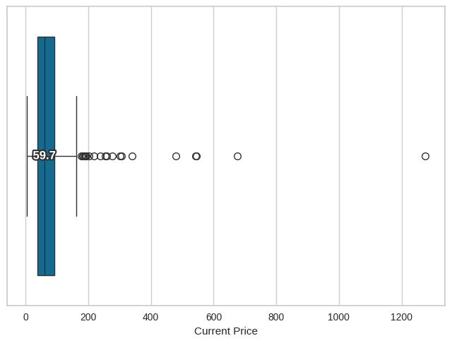

```python
# Univariate analysis for Current Price
hist('Current Price',stock_df2,True)
box('Current Price',stock_df2)
```

As you can see the median values of stock price is 59.70 dollar and average value is 80.87 dollar. It has minimum of 4.5 and maximum of 1274. It shows Right Skewness in the data.

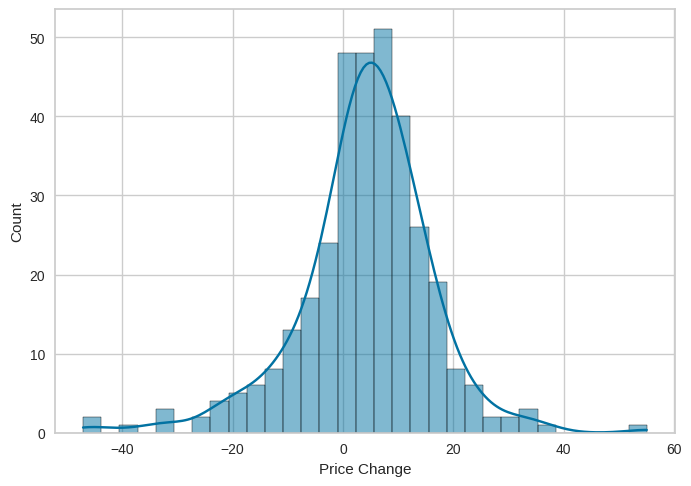

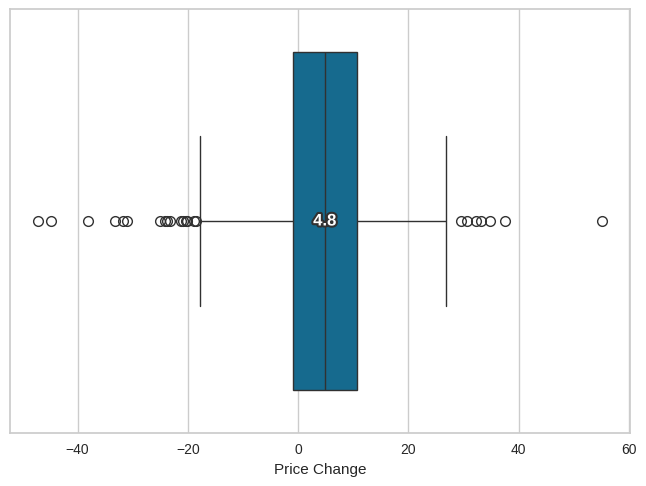

```python
# Univariate analysis for Price Change
hist('Price Change',stock_df2,True)
box('Price Change',stock_df2)
```

As you can see the median values of price change is 4.8 dollar. It has minimum of -47 and maximum of 55. It is looklike normally distributted.

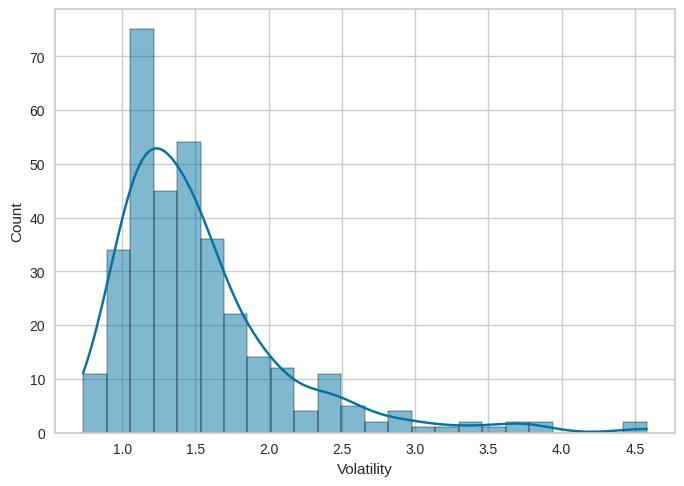

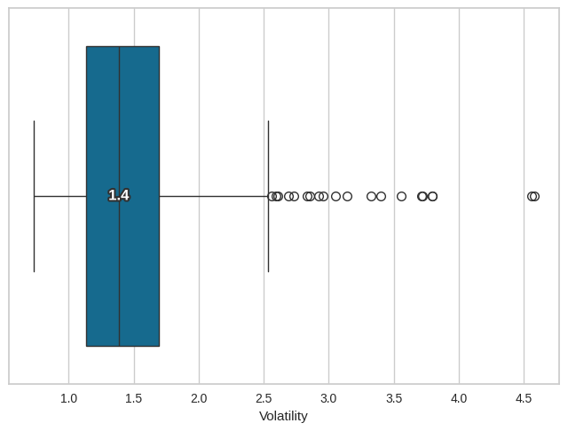

```python
# Univariate analysis for Volatility
hist('Volatility',stock_df2,True)
box('Volatility',stock_df2)
```

As you can see the median values of volatility is 1.4. It has minimum of 0.73 and maximum of 4.58. It is looklike slightly Right Skewed distribution.

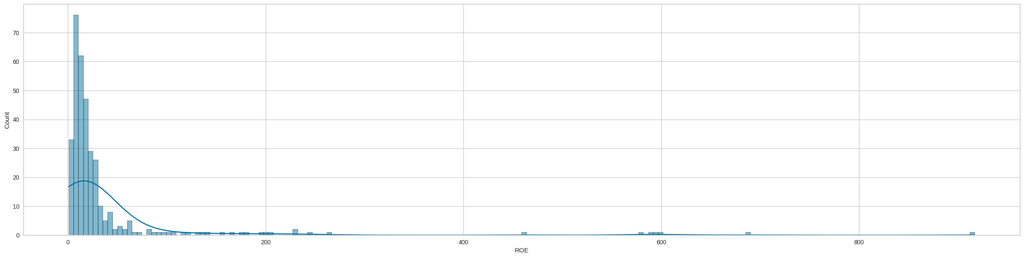

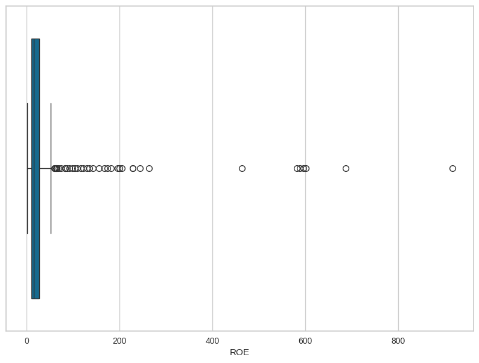

```python
# Univariate analysis for ROE
plt.figure(figsize=(30, 7))
sns.histplot(x='ROE',data=stock_df2,kde=True);
plt.figure(figsize=(10, 7))
sns.boxplot(x='ROE',data=stock_df2)
```

As you can see average values of ROE is 39.59 and median values is 15. It has minimum of 1 and maximum of 917.

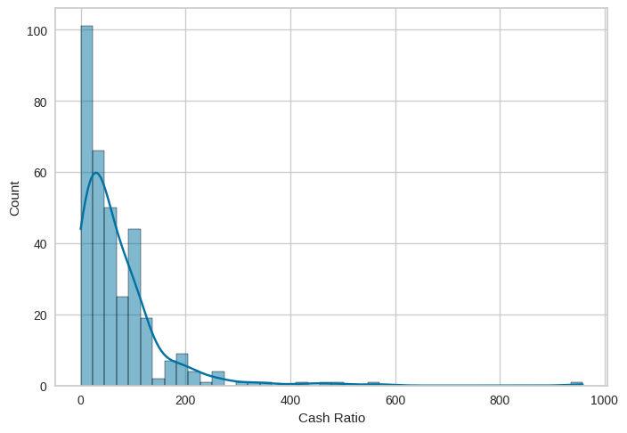

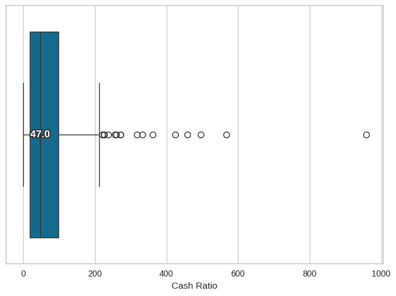

```python
# Univariate analysis for Cash Ratio
hist('Cash Ratio',stock_df2,True)
box('Cash Ratio',stock_df2)
```

As you can see Cash Ratio has median value of 47. Minimum value is 0 and maximum value is 958.

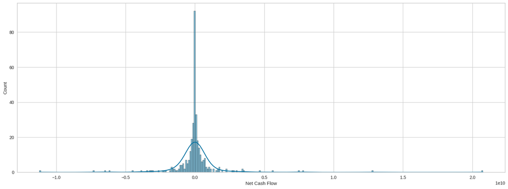

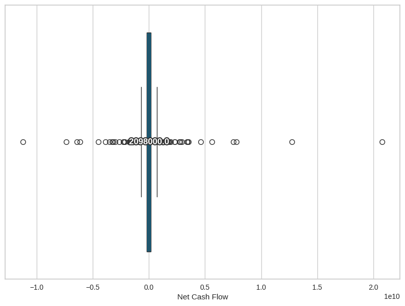

```python
# Univariate analysis for Net Cash Flow
# Univariate analysis for ROE
plt.figure(figsize=(20, 7))
sns.histplot(x='Net Cash Flow',data=stock_df2,kde=True);
plt.figure(figsize=(10, 7))
box('Net Cash Flow',stock_df2)
```

As you can see Net Cash flow has median value of 2.1 million dollar. Minimum value is -11208 million dollar and maximum value is 20764 million dollar. It is normally distributted

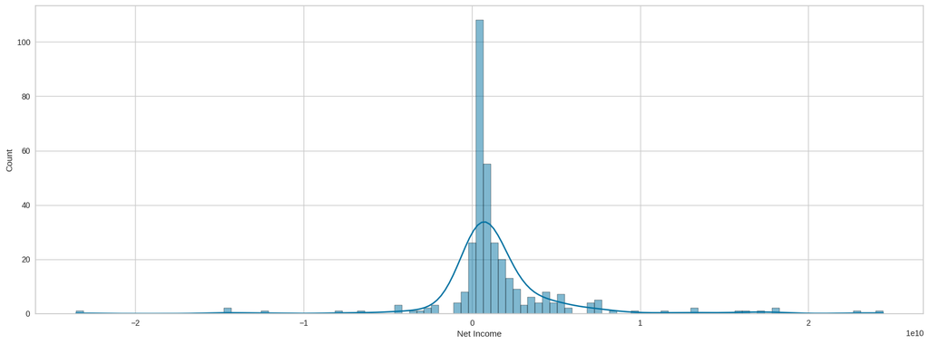

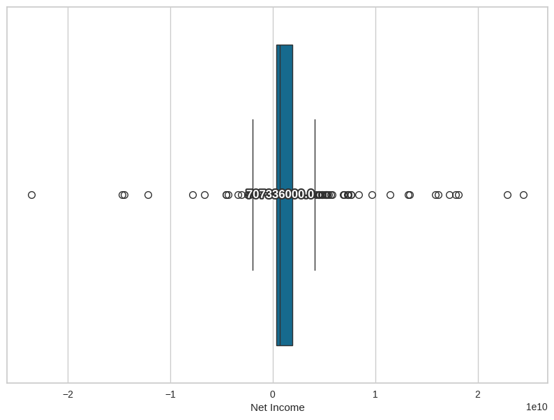

```python
# Univariate analysis for Net Income
plt.figure(figsize=(20, 7))
sns.histplot(x='Net Income',data=stock_df2,kde=True);
plt.figure(figsize=(10, 7))
box('Net Income',stock_df2)
```

As you can see Net Income has median value of 707.34 million dollar. Minimum value is -23528 million dollar and maximum of 24442 million dollar. It is normally distributted.

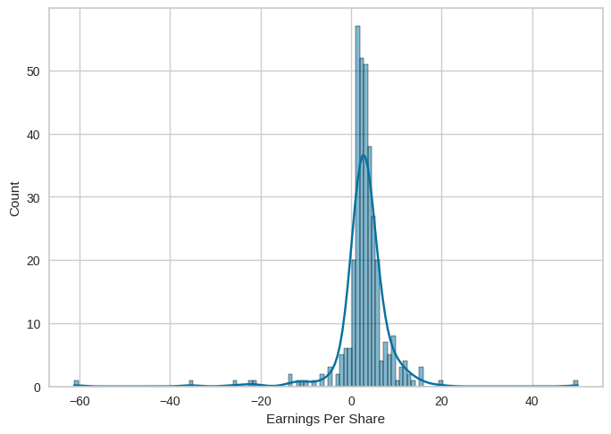

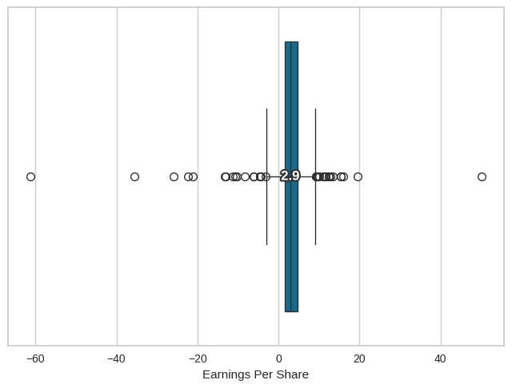

```python
# Univariate analysis for Earnings Per Share
hist('Earnings Per Share',stock_df2,True)
box('Earnings Per Share',stock_df2)
```

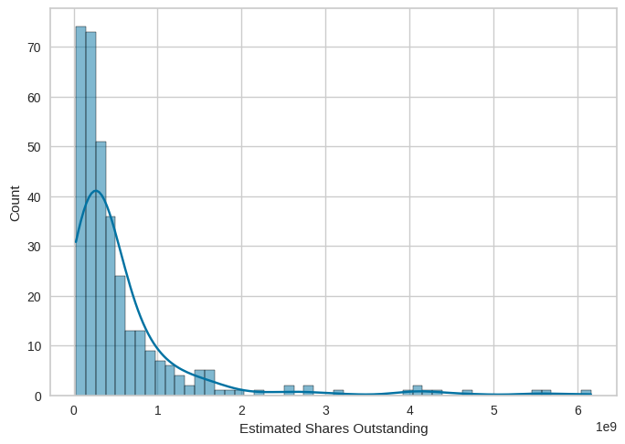

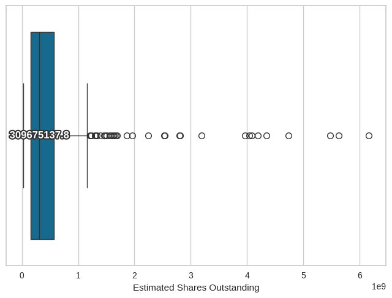

```python
# Univariate analysis for Estimated Shares Outstanding
hist('Estimated Shares Outstanding',stock_df2,True)
box('Estimated Shares Outstanding',stock_df2)
```

As you can see median values for Estimated Shares Outstanding is 309 million. It has minimum of 27 million and maximum of 6159 million.

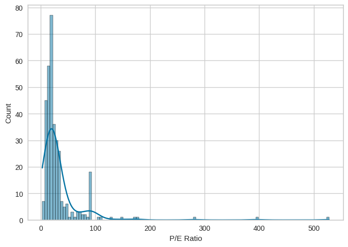

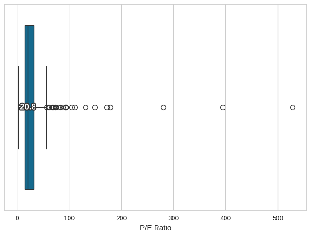

```python
# Univariate analysis for P/E Ratio
hist('P/E Ratio',stock_df2,True)
box('P/E Ratio',stock_df2)
```

As you can see P/E ratio has median of 20.8. It has minimum of 2.94 and maximum of 528.04. It has right skewness for P/E ratio.

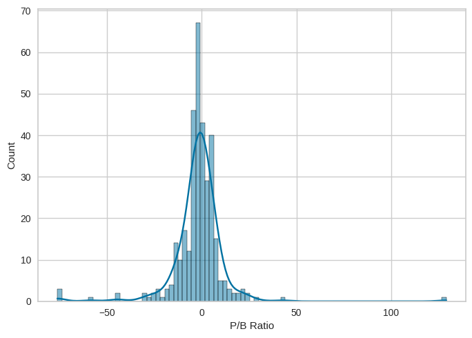

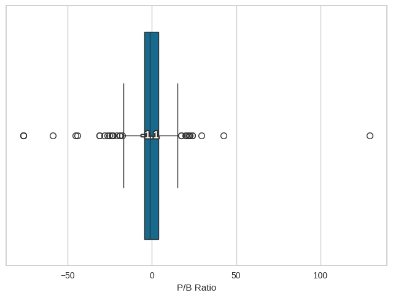

```python
# Univariate analysis for P/B Ratio
hist('P/B Ratio',stock_df2,True)
box('P/B Ratio',stock_df2)
```

As you can see P/B ratio has median value of -1.1. It has minimum value of -76.12 ans maximum value of 129.06. It is normally distributted.

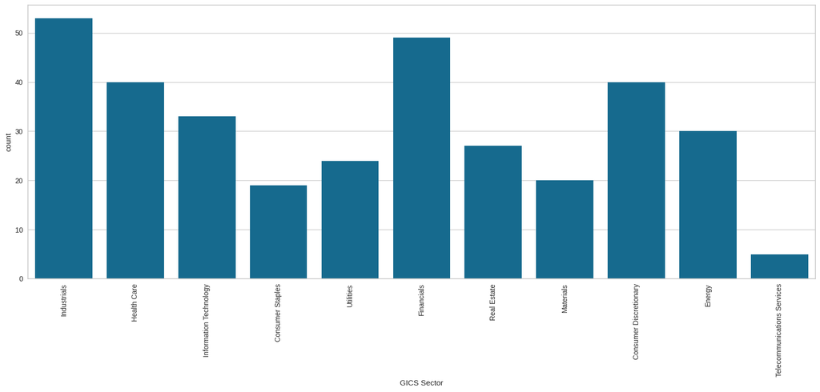

```python
# Univariate analysis for GICS Sector
plt.figure(figsize=(20, 7))
sns.countplot(x = 'GICS Sector',data = stock_df2)
plt.xticks(rotation=90);
```

As you can see Industrials sector has 53 counts followed by Financial sector with 49 counts and Consumer Discretionary has 40 counts in GICS sector.

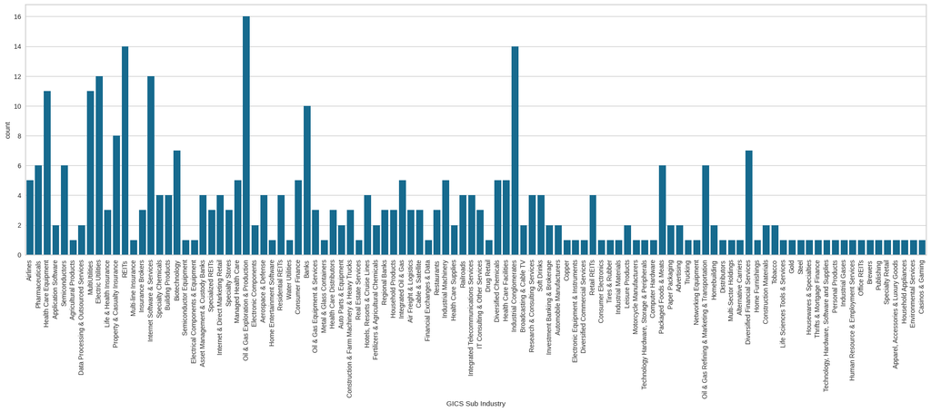

```python
# Univariate analysis for GICS Sub Industry
plt.figure(figsize=(25, 7))
sns.countplot(x = 'GICS Sub Industry',data = stock_df2)
plt.xticks(rotation=90);
```

As you can see Oil and Gas exploration and product has 16 counts followed by REIT and Industrial Conglomerates with 14 counts for GICS sub industries.

### **Bivariate Analysis**

**How are the different variables correlated with each other?**

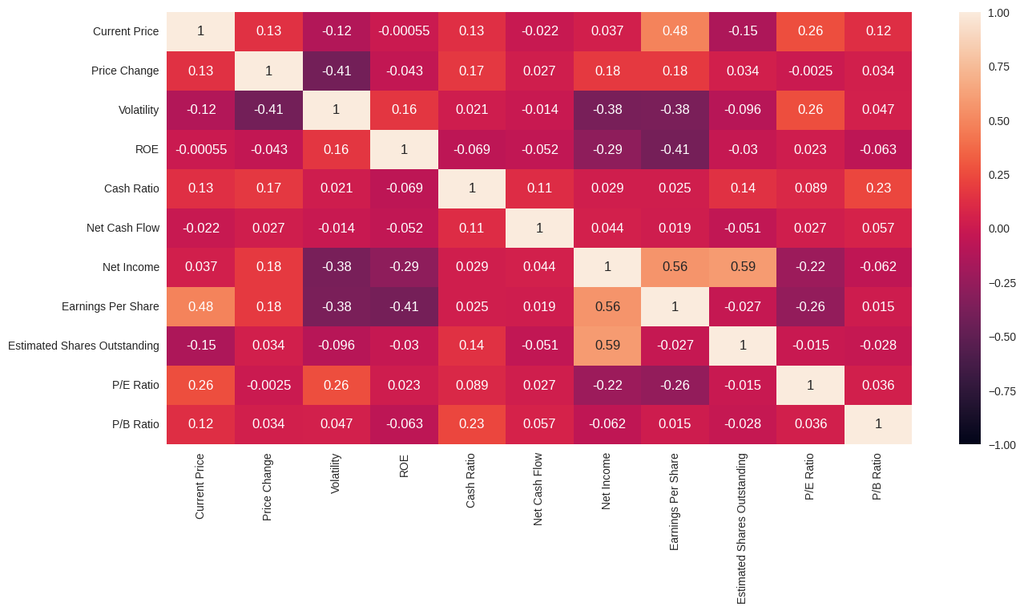

```python
# Heat plot for all numeric variable
plt.figure(figsize=(15, 7))
sns.heatmap(stock_df2.corr(), annot=True, vmin=-1, vmax=1)
plt.show()
```

Net Income has positive correaltion of 0.59 with Estimated Shares Outstanding and 0.56 with Earning per share. Earning per share has positive correaltion of 0.48 with current price of stock and negative correaltion of -0.38 with Volatility,-0.41 with ROE and -0.26 with P/E ratio.Cash Ratio is in positive correlation of 0.23 with P/B Ratio and 0.17 with price change

**The stocks of which economic sector have seen the maximum price increase on average?**

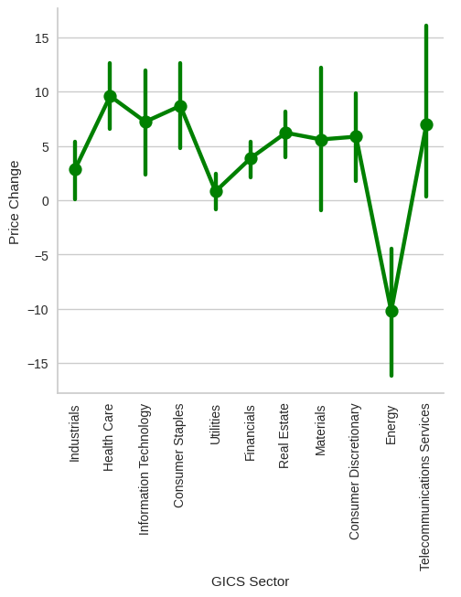

```python
# Price Change vs GICS Sector
plt.figure(figsize=(30, 7))
ax = sns.catplot(x='GICS Sector',y='Price Change',data=stock_df2,kind='point',color='Green')
plt.xticks(rotation=90);
```

```python
stock_df2.groupby('GICS Sector')['Price Change'].mean().sort_values()
```

```
GICS Sector
Energy                        -10.228289
Utilities                       0.803657
Industrials                     2.833127
Financials                      3.865406
Materials                       5.589738
Consumer Discretionary          5.846093
Real Estate                     6.205548
Telecommunications Services     6.956980
Information Technology          7.217476
Consumer Staples                8.684750
Health Care                     9.585652
Name: Price Change, dtype: float64
```

As you can see Health Care sector stock has maximum price increase on average of 9.6 followed by Consumer Staples with value of 8.7.

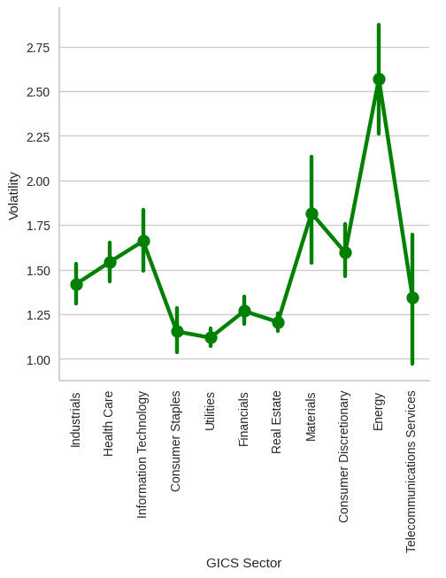

```python
# Volatility vs GICS Sector
plt.figure(figsize=(30, 7))
ax = sns.catplot(x='GICS Sector',y='Volatility',data=stock_df2,kind='point',color='Green')
plt.xticks(rotation=90);
```

As you can see Energy sector stock has maximum volatility on average about 2.55 followed by Materials with value of 1.8.

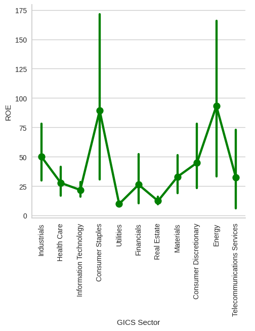

```python
# ROE vs GICS Sector
plt.figure(figsize=(30, 7))
ax = sns.catplot(x='GICS Sector',y='ROE',data=stock_df2,kind='point',color='Green')
plt.xticks(rotation=90);
```

As you can see Energy Sector and Consumer Staple has good ROE compared with all other sector.

**Cash ratio provides a measure of a company's ability to cover its short-term obligations using only cash and cash equivalents. How does the average cash ratio vary across economic sectors?**

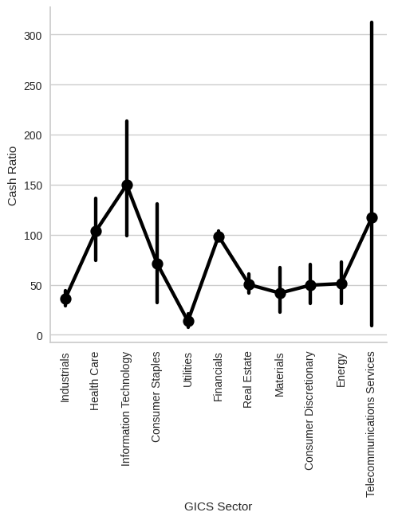

```python
# Cash Ratio vs GICS Sector
plt.figure(figsize=(30, 7))
ax = sns.catplot(x='GICS Sector',y='Cash Ratio',data=stock_df2,kind='point',color='Black')
plt.xticks(rotation=90);
```

```python
stock_df2.groupby('GICS Sector')['Cash Ratio'].mean().sort_values()
```

```
GICS Sector
Utilities                       13.625000
Industrials                     36.188679
Materials                       41.700000
Consumer Discretionary          49.575000
Real Estate                     50.111111
Energy                          51.133333
Consumer Staples                70.947368
Financials                      98.591837
Health Care                    103.775000
Telecommunications Services    117.000000
Information Technology         149.818182
Name: Cash Ratio, dtype: float64
```

As you can see Information Technology sector stock has maximum Cash Ratio on average about 149.82 followed by Telecommunications Services with value of 117.

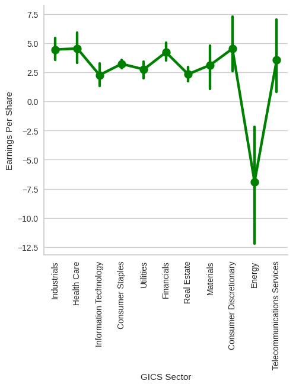

```python
#   Earning Per Share vs GICS Sector
plt.figure(figsize=(30, 7))
ax = sns.catplot(x='GICS Sector',y='Earnings Per Share',data=stock_df2,kind='point',color='Green')
plt.xticks(rotation=90);
```

As you can see Energy sector has lowest Earning per Share compared with other sectors.Industrials, Healthcare, Consumer Discretionary and Fiancial sector has almost 4-5 dollar as earning per share.

**P/E ratios can help determine the relative value of a company's shares as they signify the amount of money an investor is willing to invest in a single share of a company per dollar of its earnings. How does the P/E ratio vary, on average, across economic sectors?**

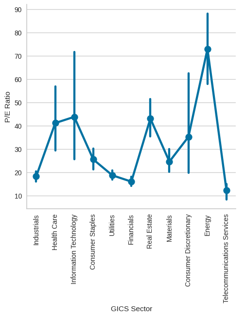

```python
# P/E Ratio vs GICS Sector
plt.figure(figsize=(30, 7))
ax = sns.catplot(x='GICS Sector',y='P/E Ratio',data=stock_df2,kind='point')
plt.xticks(rotation=90);
```

```python
stock_df2.groupby('GICS Sector')['P/E Ratio'].mean().sort_values()
```

```
GICS Sector
Telecommunications Services    12.222578
Financials                     16.023151
Industrials                    18.259380
Utilities                      18.719412
Materials                      24.585352
Consumer Staples               25.521195
Consumer Discretionary         35.211613
Health Care                    41.135272
Real Estate                    43.065585
Information Technology         43.782546
Energy                         72.897709
Name: P/E Ratio, dtype: float64
```

As you can see Telecommunications services has lowest P/E Ratio of 12.22 and Energy sector has highest P/E ratio of 72.9.

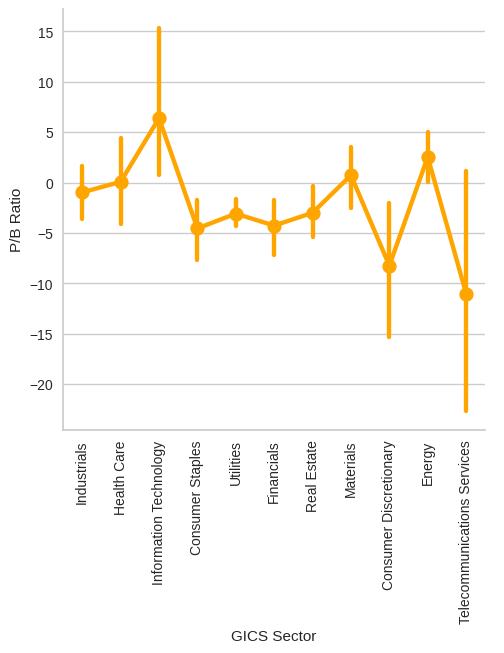

```python
# P/B vs GICS Sector
plt.figure(figsize=(30, 7))
ax = sns.catplot(x='GICS Sector',y='P/B Ratio',data=stock_df2,kind='point',color='Orange')
plt.xticks(rotation=90);
```

```python
stock_df2.groupby('GICS Sector')['P/B Ratio'].mean().sort_values()
```

```
GICS Sector
Telecommunications Services   -11.009858
Consumer Discretionary         -8.253543
Consumer Staples               -4.554003
Financials                     -4.270505
Utilities                      -3.087350
Real Estate                    -3.003320
Industrials                    -0.979266
Health Care                     0.068869
Materials                       0.723103
Energy                          2.539738
Information Technology          6.377128
Name: P/B Ratio, dtype: float64
```

As you can see Information Technology sector has highest P/B ratio of about 6.37 and Telecommunications services sector has lowest P/B ratio of about -11. Material sector has good P/B ratio.